# Tests of Significance – 1 Formulation of Hypotheses and Types of errors

# -------------------------------------------------------------------------------------------

# Tests of Significance – 2 Tests Concerning Single Population Mean

### One-Sample t-test:

### Objective:

To determine whether the mean of a sample is significantly different from a hypothesized population mean.

#### Assumptions:

1. The data are independent and identically distributed.
2. The population from which the sample is drawn is approximately normally distributed.
3. The standard deviation of the population is unknown.

#### STEPS:

1. Formulate the null hypothesis (H0) and alternative hypothesis (H1).
2. Select a significance level (α).
3. Calculate the test statistic using the formula
4. Determine the degrees of freedom (df=n−1).
5. Determine the critical value from the t-distribution table or use statistical software.
6. Compare the calculated t-statistic with the critical value.
7. Make a decision:

If |t| > t critical, reject the null hypothesis.

If |t| <= t critical, fail to reject the null hypothesis.

# Example 1:

```python
import numpy as np
from scipy import stats
```

```python
data = np.array([25, 30, 35, 40, 45])
```

## Hypothesis testing

Null hypothesis: mean = 30

Alternative hypothesis: mean != 30

```python
null_mean = 30
alpha = 0.05
df = 4
```

##### One-sample t-test

```python
t_statistic, p_value = stats.ttest_1samp(data, null_mean)
```

```python
print("T-statistic:", t_statistic)
print("P-value:", p_value)
```

```
T-statistic: 1.414213562373095
P-value: 0.23019964108049873
```

```python
if p_value < alpha:
    print("Reject null hypothesis")
else:
    print("Fail to reject null hypothesis")
```

```
Fail to reject null hypothesis
```

```python
from scipy.stats import t

t_critical = t.ppf(1 - alpha/2, df)  # For two-tailed test alpha/2
t_critical
```

```
2.7764451051977987
```

# ----------------------------------------------------------------------------------------

# Tests of Significance – 3: Tests Concerning Two Populations Mean

### Independent Samples t-test:

#### Objective:

To determine whether the means of two independent samples are significantly different from each other.

#### Assumptions:

1. The data in each sample are independent and identically distributed.
2. Both populations from which the samples are drawn are approximately normally distributed.
3. The variances of the two populations are equal (homogeneity of variances) or approximately equal (if variances are not equal, a Welch's t-test can be used).

##### STEPS:

1. Formulate the null hypothesis (H0) and alternative hypothesis (H1).
2. Select a significance level (α).
3. Calculate the test statistic using the formula
4. Determine the degrees of freedom (df = n1 + n2 -2).
5. Determine the critical value from the t-distribution table or use statistical software.
6. Compare the calculated t-statistic with the critical value.
7. Make a decision:

If |t| > t critical, reject the null hypothesis.

If |t| <= t critical, fail to reject the null hypothesis.

```python
import numpy as np
from scipy import stats
```

```python
data1 = np.array([20,25,30,35,40,45])
data2 = np.array([25,26,27,28,29,30])
```

```python
alpha = 0.05
df = 10
```

#### Independent t-test

```python
t_statistic, p_value = stats.ttest_ind(data1, data2)
```

```python
print("T-statistic:", t_statistic)
print("P-value:", p_value)
```

```
T-statistic: 1.2838814775327387
P-value: 0.22813269748802126
```

```python
if p_value < alpha:
    print("Reject null hypothesis")
else:
    print("Fail to reject null hypothesis")
```

```
Fail to reject null hypothesis
```

```python
from scipy.stats import t

t_critical = t.ppf(1 - alpha/2, df)  # For two-tailed test
t_critical
```

```
2.2281388519649385
```

# -------------------------------------------------------------------------------------------

### Paired T Test

```python
from scipy import stats

before = [25, 30, 35, 40, 45]
after = [20, 28, 32, 38, 42]
```

```python
# Perform paired t-test
t_statistic, p_value = stats.ttest_rel(before, after)
```

```python
print("T-statistic:", t_statistic)
print("P-value:", p_value)
```

```
T-statistic: 5.477225575051661
P-value: 0.0054084788647625745
```

```python
alpha = 0.05
if p_value < alpha:
    print("Reject the null hypothesis: There is a significant difference between the measurements.")
else:
    print("Fail to reject the null hypothesis: There is no significant difference between the measurements.")
```

```
Reject the null hypothesis: There is a significant difference between the measurements.
```

# ---------------------------------------------------------------------------------------

# Tests of Significance – 4: Tests Concerning Population Variance.

### Chi-square Test for Variance:

#### Objective:

To determine whether the variance of a population is significantly different from a hypothesized value.

#### Assumptions:

1. The data are independent and identically distributed.
2. The population from which the sample is drawn follows a normal distribution.
3. The sample is randomly selected.

#### Steps:

1. Formulate the null hypothesis (H0) and alternative hypothesis (H1).
2. Select a significance level (α).
3. Calculate the sample variance ( S^2)
4. Calculate the chi-square statistic using the formula
5. Determine the degrees of freedom (df=n−1)
6. Determine the critical value from the chi-square distribution table or use statistical software.
7. Compare the calculated chi-square statistic with the critical value.
8. Make a decision:

If the calculated chi-square statistic is greater than the critical value, reject the null hypothesis.

If the calculated chi-square statistic is less than or equal to the critical value, fail to reject the null hypothesis.

```python
import numpy as np
from scipy import stats
```

```python
data = np.array([25, 30, 35, 40, 45])
```

#### Hypothesis testing

Null hypothesis: variance = 25

Alternative hypothesis: variance != 25

```python
null_variance = 25
alpha = 0.05
df = 4
```

#### Chi-square test

```python
chi_square_statistic, p_value = stats.chisquare(data)
```

```python
print("Chi-square statistic:", chi_square_statistic)
print("P-value:", p_value)
```

```
Chi-square statistic: 7.142857142857142
P-value: 0.12852873028101505
```

```python
if p_value < alpha:
    print("Reject null hypothesis")
else:
    print("Fail to reject null hypothesis")
```

```
Fail to reject null hypothesis
```

```python
from scipy.stats import chi2
chi_square_critical = chi2.ppf(1 - alpha, df)

print("Chi-square Critical Value:", chi_square_critical)
```

```
Chi-square Critical Value: 9.487729036781154
```

# --------------------------------------------------------------------------------------

# EXAMPLE WITH DATASET

##### ONE SAMPLE T TEST

```python
import pandas as pd
from scipy import stats

data = pd.read_csv("C:/Users/Aaron/Downloads/screen_size-data.csv")
data
```

|  | Screen_size(in cm) |
| --- | --- |
| 0 | 10.006692 |
| 1 | 10.081624 |
| 2 | 10.072873 |
| 3 | 9.954496 |
| 4 | 9.994093 |
| ... | ... |
| 995 | 10.034021 |
| 996 | 10.068130 |
| 997 | 9.969032 |
| 998 | 9.939579 |
| 999 | 9.865479 |

1000 rows × 1 columns

```python
screen_size_data = data['Screen_size(in cm)']
```

##### TESTING ASSUMPTIONS

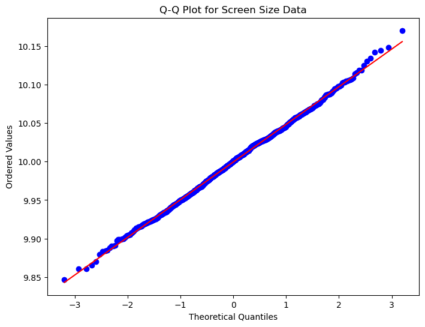

```python
import matplotlib.pyplot as plt
plt.figure(figsize=(8, 6))
stats.probplot(screen_size_data, dist="norm", plot=plt)
plt.title('Q-Q Plot for Screen Size Data')
plt.xlabel('Theoretical Quantiles')
plt.ylabel('Ordered Values')
plt.show()
```

```python
hypothesized_mean = 10
alpha = 0.05
```

```python
t_statistic, p_value = stats.ttest_1samp(screen_size_data, hypothesized_mean)
```

```python
print("One-sample t-test results:")
print("T-statistic:", t_statistic)
print("P-value:", p_value)
```

```
One-sample t-test results:
T-statistic: -0.3954815298073675
P-value: 0.6925719857853037
```

```python
if p_value < alpha:
    print("Reject the null hypothesis: The mean screen size is significantly different from the hypothesized mean.")
else:
    print("Fail to reject the null hypothesis: There is no significant difference in the mean screen size.")
```

[output not shown]

# -------------------------------------------------------------------------------------------------

## Independent T test

```python
import pandas as pd
from scipy import stats

data = pd.read_csv("C:/Users/Aaron/Downloads/ind.csv")
data
```

|  | screensize_sample1 | screensize_sample2 |
| --- | --- | --- |
| 0 | 9.995571 | 10.018528 |
| 1 | 9.989146 | 9.973087 |
| 2 | 10.019307 | 10.027963 |
| 3 | 10.047096 | 9.964532 |
| 4 | 9.958848 | 10.063205 |
| ... | ... | ... |
| 995 | 9.968979 | 10.030389 |
| 996 | 9.964215 | 10.005841 |
| 997 | 9.935061 | 10.011966 |
| 998 | 10.044726 | 9.962298 |
| 999 | 9.959991 | 9.996642 |

1000 rows × 2 columns

```python
sample1 = data['screensize_sample1']
sample2 = data['screensize_sample2']
```

```python
statistic, p_value = stats.levene(sample1, sample2)
print("\nLevene's Test for Homogeneity of Variance:")
print("Statistic:", statistic)
print("P-value:", p_value)
```

```
Levene's Test for Homogeneity of Variance:
Statistic: 0.008827540517231008
P-value: 0.9251543302843457
```

```python
variance_sample1 = np.var(sample1, ddof=1)  # ddof=1 to calculate sample variance (N-1)
variance_sample2 = np.var(sample2, ddof=1)

print("Variance of Sample 1:", variance_sample1)
print("Variance of Sample 2:", variance_sample2)
```

```
Variance of Sample 1: 0.002382830036427738
Variance of Sample 2: 0.0023535852370879687
```

##### Both are same

```python
from scipy.stats import ttest_ind
t_statistic, p_value = ttest_ind(sample1, sample2)
```

```python
print("T-statistic:", t_statistic)
print("P-value:", p_value)
```

```
T-statistic: 1.307232478816939
P-value: 0.1912841837210569
```

```python
alpha = 0.05
if p_value < alpha:
    print("Reject the null hypothesis: There is a significant difference between the means of the two samples.")
else:
    print("Fail to reject the null hypothesis: There is no significant difference between the means of the two samples.")
```

```
Fail to reject the null hypothesis: There is no significant difference between the means of the two samples.
```

# --------------------------------------------------------------------------------------------------------------

# Paired T Test

```python
import pandas as pd
from scipy import stats
import matplotlib.pyplot as plt
from scipy.stats import ttest_rel,probplot

data = pd.read_csv("C:/Users/Aaron/Downloads/paired1.csv")
data
```

|  | tyre_1 | tyre_2 |
| --- | --- | --- |
| 0 | 19849.129768 | 21269.833456 |
| 1 | 19836.808864 | 23076.428934 |
| 2 | 20750.418253 | 21859.519081 |
| 3 | 20191.545679 | 24227.202129 |
| 4 | 21131.215098 | 21940.674798 |
| 5 | 20120.140834 | 21313.801473 |
| 6 | 19726.700591 | 22086.812520 |
| 7 | 20561.694760 | 21859.068689 |
| 8 | 21289.185547 | 19275.006258 |
| 9 | 21420.557835 | 23060.536592 |
| 10 | 21306.782322 | 22591.711319 |
| 11 | 19667.478002 | 22685.073225 |
| 12 | 20144.263012 | 21340.406245 |
| 13 | 20839.783177 | 20502.471680 |
| 14 | 20255.295569 | 23233.119885 |
| 15 | 18766.760500 | 21855.602981 |
| 16 | 20509.418309 | 22204.226382 |
| 17 | 22014.051918 | 22200.366097 |
| 18 | 17792.334494 | 23098.206975 |
| 19 | 21136.352480 | 22447.635939 |
| 20 | 21509.007556 | 22671.030070 |
| 21 | 19828.207604 | 21568.890928 |
| 22 | 19792.099802 | 21061.822717 |
| 23 | 21368.476579 | 22329.824174 |
| 24 | 21110.656237 | 20703.396797 |

```python
tyre_1 = data['tyre_1']
tyre_2 = data['tyre_2']
```

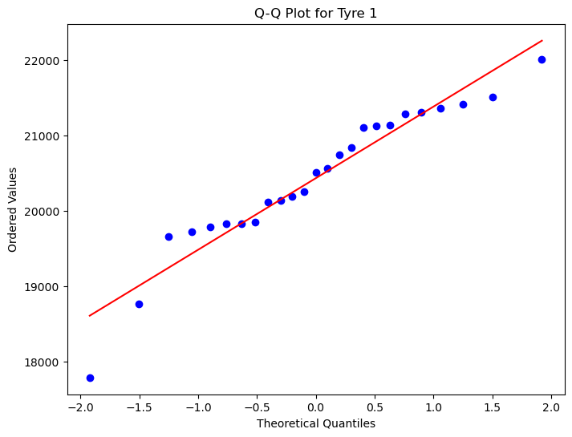

```python
# Q-Q plot for tyre 1
plt.figure(figsize=(8, 6))
probplot(tyre_1, dist="norm", plot=plt)
plt.title('Q-Q Plot for Tyre 1')
plt.xlabel('Theoretical Quantiles')
plt.ylabel('Ordered Values')
plt.show()
```

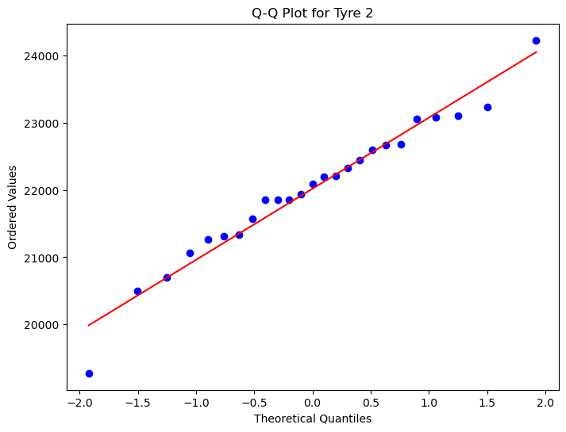

```python
# Q-Q plot for tyre 2
plt.figure(figsize=(8, 6))
probplot(tyre_2, dist="norm", plot=plt)
plt.title('Q-Q Plot for Tyre 2')
plt.xlabel('Theoretical Quantiles')
plt.ylabel('Ordered Values')
plt.show()
```

```python
t_statistic, p_value = ttest_rel(tyre_1, tyre_2)
```

```python
print("T-statistic:", t_statistic)
print("P-value:", p_value)
```

```
T-statistic: -5.266185631213928
P-value: 2.1211171771756464e-05
```

```python
if p_value < alpha:
    print("Reject the null hypothesis: There is a significant difference between the means of the two paired samples.")
else:
    print("Fail to reject the null hypothesis: There is no significant difference between the means of the two paired samples.")
```

```
Reject the null hypothesis: There is a significant difference between the means of the two paired samples.
```

###### We can reject the null hypothesis at a 95% confidence interval and conclude that there is a significant difference between the means of tires before and after the rubber material replacement.

###### The negative mean in the difference depicts that the average kilometers covered by tire 2 are more than the average kilometers covered by tire 1.

# ----------------------------------------------------------------------------------------------

# Pearson's Chi-Square Test

```python
import numpy as np
from scipy.stats import chi2_contingency
```

```python
# Number of Girls Vs Boys of BDA Mode of Commuting
observed = np.array([[50, 30], [20, 40], [30, 20]])
```

```python
chi2, p, dof, expected = chi2_contingency(observed)
```

```python
print("Chi-Square Statistic:", chi2)
print("p-value:", p)
print("Degrees of Freedom:", dof)
print("Expected Frequencies:")
print(expected)
```

```
Chi-Square Statistic: 13.17685185185185
p-value: 0.0013762045074339135
Degrees of Freedom: 2
Expected Frequencies:
[[42.10526316 37.89473684]
 [31.57894737 28.42105263]
 [26.31578947 23.68421053]]
```

# -------------------------------------------------------------------------------------------------------

# Goodness of Fit Test

```python
from scipy.stats import chisquare
```

```python
observed = np.array([20, 30, 40])
expected = np.array([30, 30, 30])   # Expected frequencies (for uniform distribution)
```

```python
chi2, p = chisquare(observed, expected)
```

```python
print("Chi-Square Statistic:", chi2)
print("p-value:", p)
```

[output not shown]

# ----------------------------------------------------------------------------------------------------------

# Chi-Square Test of Independence:

```python
import numpy as np
from scipy.stats import chi2_contingency
```

[output not shown]

```python
# Academic Performance Vs ECA
observed = np.array([[30, 25, 10, 5], [20, 35, 15, 10]])
```

```python
chi2, p, dof, expected = chi2_contingency(observed)
```

```python
print("Chi-Square Statistic:", chi2)
print("p-value:", p)
print("Degrees of Freedom:", dof)
print("Expected Frequencies:")
print(expected)
```

[output not shown]

# ---------------------------------------------------------------------------------------------------------